# Economics 2590 Fall 2021 Final Project

Blenda Hoang, Alexander Chin, Daniel Lavarte

11/15/21

## Abstract

- Many factors influence whether banks approve consumers for credit cards or not. Traditionally, income is one of the biggest considerations in the process. But how do banks judge consumers who are self employed and whose income is inevitably more volatile? We seek to answer this question by reviewing 13,444 credit card applications and their subsequent approval/denial status. Through both linear probability and probit regression models, we find that self employed individuals are indeed less likely to be approved for a credit card than equal individuals who are employed alternatively.

## Question and Associated Hypothesis

**Question of Interest**:

- Does being self-employed impact likelihood of credit card approval?

B1 = coefficient on self employed regressor in our data set  
Null Hypothesis - Ho: B1 = 0  
Alternative Hypothesis - Ha: B1 ≠ 0

## Data

Data Source: *https://www.kaggle.com/surekharamireddy/credit-data*  
This data set covers 13,444 observations and the following 14 descriptive variables about retail credit card data.

1. **APPROVED**: 1 if application for credit card is accepted, 0 if not
2. **DEFAULT**: 1 if defaulted, 0 if not (observed when CARDHLDR=1, 10,499 observations)
3. **AGE**: Age in years plus twelfths of a year
4. **ACADMOS**: Months living at current address
5. **ADEPCNT**: 1 + number of dependents
6. **MAJORDRG**: Number of major derogatory reports
7. **MINORDRG**: Number of minor derogatory reports
8. **OWNRENT**: 1 if owns their home, 0 if rent
9. **INCOME**: Monthly income in INR currency (divided by 10,000)
10. **SELFEMPL**: 1 if self employed, 0 if not
11. **INCPER**: Income divided by number of dependents
12. **EXP_INC**: Ratio of monthly credit card expenditure to yearly income
13. **SPENDING**: Average monthly credit card expenditure (for CARDHOLDER = 1)
14. **LOGSPEND**: Log of spending

## Descriptive Statistics

```
Descriptive Statistics
==========================================================
Statistic                    N     Mean   Median  St. Dev.
----------------------------------------------------------
Monthly Income             13,444 2,509.5 2,166.7 1,252.9
Avg Monthly CC Expenditure 10,499  227.0   140.0   294.1
Age                        13,444  33.5    31.5     10.2
Approved                   13,444   0.8      1      0.4
Payment Default            13,444   0.1      0      0.3
Number of Dependents       13,444   1.0      1      1.3
Self-Employed              13,444   0.1      0      0.2
----------------------------------------------------------
```

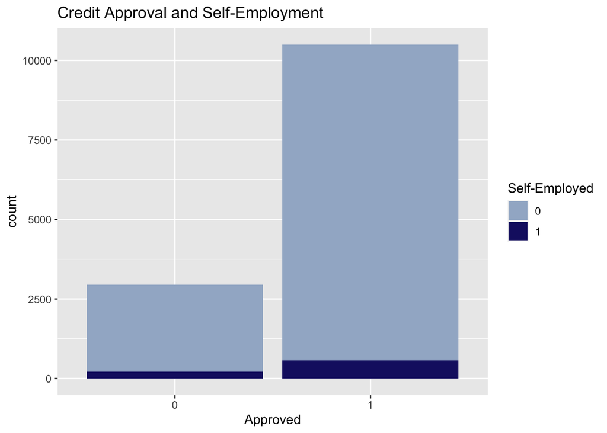

```
               Not Self-employed Self-employed
  Not Approved              2729           216
  Approved                  9936           563
```

```
               Not Self-employed Self-employed
  Not Approved         0.2154757     0.2772786
  Approved             0.7845243     0.7227214
```

**Is there a relationship between being self-employed and the likelihood of being approved for a credit card?**

- Based off our observations from the graph and table above, those who are self-employed have a higher proportion of rejected credit card applications than those who aren’t. However, the difference between proportions isn’t large enough to wholly attribute credit card application denial to employment status hence there are likely other factors that need to be considered.

## Binary Outcome Variable Regression Analysis

```
Credit Card Approval Linear Probability Model Regressions
======================================================================
                                    Dependent variable:
                     -------------------------------------------------
                                         Approved
                       (1)     (2)     (3)     (4)     (5)      (6)
----------------------------------------------------------------------
SELFEMPL             -0.062  -0.099  -0.098  -0.097   -0.098   -0.056
                     (0.016) (0.016) (0.015) (0.015) (0.015)  (0.031)

I(INCOME/1000)                0.051   0.047   0.053   0.052    0.054
                             (0.003) (0.003) (0.003) (0.003)  (0.003)

OWNRENT                               0.045   0.061   0.058    0.057
                                     (0.007) (0.007) (0.007)  (0.007)

MAJORDRG                             -0.122  -0.121   -0.121   -0.121
                                     (0.004) (0.004) (0.004)  (0.004)

ADEPCNT                                      -0.025   -0.026   -0.026
                                             (0.003) (0.003)  (0.003)

AGE                                                   0.001    0.001
                                                     (0.0004) (0.0004)

SELFEMPL_INTERACTION                                           -0.013
                                                              (0.008)

Constant              0.785   0.660   0.704   0.708   0.692    0.689
                     (0.004) (0.008) (0.008) (0.007) (0.012)  (0.012)

----------------------------------------------------------------------
Observations         13,444  13,444  13,444  13,444   13,444   13,444
R2                    0.001   0.024   0.206   0.211   0.212    0.212
Adjusted R2           0.001   0.024   0.206   0.211   0.211    0.211
Residual Std. Error   0.413   0.409   0.369   0.367   0.367    0.367
F Statistic          16.403  167.290 871.782 720.103 600.705  515.396
======================================================================
Note:                                                               NA
```

```
Linear hypothesis test

Hypothesis:
SELFEMPL_INTERACTION = 0
AGE = 0

Model 1: restricted model
Model 2: Approved ~ SELFEMPL + I(INCOME/1000) + OWNRENT + MAJORDRG + ADEPCNT +
    AGE + SELFEMPL_INTERACTION

Note: Coefficient covariance matrix supplied.

  Res.Df Df      F  Pr(>F)
1  13438
2  13436  2 3.1022 0.04498 *
---
Signif. codes:  0 '***' 0.001 '**' 0.01 '*' 0.05 '.' 0.1 ' ' 1
```

```
Linear hypothesis test

Hypothesis:
SELFEMPL_INTERACTION = 0

Model 1: restricted model
Model 2: Approved ~ SELFEMPL + I(INCOME/1000) + OWNRENT + MAJORDRG + ADEPCNT +
    AGE + SELFEMPL_INTERACTION

Note: Coefficient covariance matrix supplied.

  Res.Df Df      F  Pr(>F)
1  13437
2  13436  1 2.9155 0.08775 .
---
Signif. codes:  0 '***' 0.001 '**' 0.01 '*' 0.05 '.' 0.1 ' ' 1
```

**Linear Probability Model Regression Analysis**

- The outcome variable for all our regression specifications is Approved which takes the value of 1 if the applicant is approved for a credit card and 0 otherwise. Regression 1 regresses our main variable of interest SELFEML on the variable Approved. According to this initial simple regression, if an applicant is self-employed, they have a 6.2% lower chance of being approved for a credit card.
- After testing multiple control variables, we decide that our baseline regression in the Linear Probability Model is Regression 5. While adding on the “Age” control variable in Regression 5 doesn’t change our adjusted R-squared value from Regression 4, this variable is statistically significant at 95% levels (t=2.5). In Regression 6, we add on the interaction term between SELFEMPL and INCOME; however, this does not change our R-squared value and is not statistically significant (t=1.625). Additionally, the F-test value for the interaction term in Regression 6 is 2.9 (which is below the F critical value of 3.84), hence we can conclude this term is not needed to retain in our baseline model. The result from our baseline regression is interpreted as if someone were self-employed, they would have 9.8% less chance of being approved for a credit card, all other factors equal.
- Now, when interpreting some of our other control variables in our baseline specification (Regression 5), if the credit card applicant owns their home they have a 5.8% higher chance of being approved holding all other variables constant. For each additional major derogatory report an applicant has, their likelihood of being approved for a loan decreases by 12.1% holding all other variables constant. An increase in income by 10 million INR will increase the probability of being approved for a credit card by 5.2% holding all other variables constant. It is also important to note that all variables in this specification are statistically significant at a 95% confidence level.

**Omitted Variable Bias**

- We observe our original regression on the SELFEMPL term as suffering from omitted variable upward bias as compared to our baseline specification. The coefficient on SELFEMPL in Regression 1 is -0.062 compared to -0.098 in Regression 5.

However, the issue with the LPM model is the probabilities of being approved or denied can be <0 or >1 which is outside the normal boundaries of probability (0 <= p <=1). Given this nuance of the LPM model, we also run this regression using the Probit Model below in which this issue is resolved.

```
Credit Card Approvals Probit Regressions
======================================================================================
                                            Dependent variable:
                     -----------------------------------------------------------------
                                                 Approved
                        (1)        (2)        (3)        (4)        (5)        (6)
--------------------------------------------------------------------------------------
SELFEMPL               -0.197     -0.336     -0.425     -0.417     -0.430     -0.035
                      (0.049)    (0.051)    (0.056)    (0.056)    (0.056)    (0.115)

I(INCOME/1000)                    0.205      0.269      0.290      0.283      0.309
                                 (0.012)    (0.015)    (0.015)    (0.015)    (0.017)

OWNRENT                                      0.218      0.278      0.250      0.247
                                            (0.029)    (0.030)    (0.031)    (0.031)

MAJORDRG                                     -0.703     -0.698     -0.703     -0.705
                                            (0.018)    (0.018)    (0.018)    (0.018)

ADEPCNT                                                 -0.097     -0.101     -0.103
                                                       (0.011)    (0.011)    (0.011)

AGE                                                                0.005      0.005
                                                                  (0.002)    (0.002)

SELFEMPL_INTERACTION                                                          -0.142
                                                                             (0.036)

Constant               0.788      0.306      0.400      0.423      0.295      0.251
                      (0.012)    (0.030)    (0.034)    (0.034)    (0.052)    (0.053)

--------------------------------------------------------------------------------------
Observations           13,444     13,444     13,444     13,444     13,444     13,444
Log Likelihood       -7,059.902 -6,884.797 -5,478.426 -5,442.346 -5,436.898 -5,429.167
======================================================================================
Note:                                                                               NA
```

```
                    Pseudo R-Squared
Probit Regression 1      0.001098742
Probit Regression 2      0.025874198
Probit Regression 3      0.224860839
Probit Regression 4      0.229965758
Probit Regression 5      0.230736591
Probit Regression 6      0.231830394
```

```
Probit Regressions - Average Marginal Effects
====================================================================
                                   Dependent variable:
                     -----------------------------------------------
                                        Approved
                       (1)     (2)     (3)     (4)     (5)     (6)
--------------------------------------------------------------------
SELFEMPL             -0.062  -0.108  -0.138  -0.134  -0.139  -0.010
                     (0.016) (0.018) (0.020) (0.020) (0.020) (0.033)

I(INCOME/1000)                0.059   0.076   0.082   0.080   0.087
                             (0.003) (0.004) (0.004) (0.004) (0.005)

OWNRENT                               0.061   0.078   0.070   0.069
                                     (0.008) (0.008) (0.009) (0.009)

MAJORDRG                             -0.199  -0.197  -0.199  -0.199
                                     (0.006) (0.006) (0.006) (0.006)

ADEPCNT                                      -0.027  -0.028  -0.029
                                             (0.003) (0.003) (0.003)

AGE                                                   0.001   0.001
                                                     (0.000) (0.000)

SELFEMPL_INTERACTION                                         -0.040
                                                             (0.010)

Constant              0.232   0.089   0.113   0.119   0.083   0.071
                     (0.002) (0.009) (0.010) (0.010) (0.015) (0.015)

--------------------------------------------------------------------
Observations         13,444  13,444  13,444  13,444  13,444  13,444
====================================================================
Note:                                                             NA
```

**Probit Model Regression Analysis**

- When looking at Regression 1, which is our simple regression of SELFEMPL on Approved, if an applicant is self-employed they have a 6.2% lower chance of being approved for a credit card.
- However, after testing out different control variables and including an interaction term, we observe Regression 6 to be our baseline regression in our Probit model. This model has the highest pseudo R-squared value, explaining 23.18% of the variance in credit card approval. However, the SELFEMPL variable in Regression 6 is no longer statistically significant as compared to Regression 5 while the interaction between SELFEMPL and INCOME is statistically significant. Note this is the opposite effect from the Linear Probability Model. The result from our baseline regression is interpreted as if someone were self-employed, they would have a 1% + (4 * monthly income in 10 millions)% lower chance of being approved for a credit card (holding all else constant) than someone who was not self-employed.
- Now, when interpreting some of our other control variables in our baseline specification, if the credit card applicant owns their home they have a 6.9% higher chance of being approved holding all other variables constant. For each additional major derogatory report an applicant has, their likelihood of being approved for a loan decreases by 19.9% holding all other variables constant. If the applicant is self employed, an increase in income by 10 million INR will increase their probability of being approved for a credit card by 4.7% holding all other variables constant. If they are not self employed, an increase in income by 10 million INR will increase their probability of being approved for a credit card by 8.7% holding all other variables constant. When looking at the magnitude of our coefficients, the increase in derogatory reports has the largest affect on the probability of being approved for a credit card when compared to the coefficients of other variables. It is also important to note that all variables in this specification are statistically significant at a 95% confidence level aside from SELFEMPL.

**Omitted Variable Bias**

- Once we include the interaction term between self-employment and income, we observe that SELFEMPL and INCOME term in Regression 5 suffers from omitted variable downward bias. There are marginal changes to the coefficients of the other regressors. Note that Regression 1 also suffers from omitted variable downward bias.

## Conclusion

- In conclusion, all findings indicate that being self employed negatively affects one’s ability to be approved for a credit card. While our analysis cannot be generalized to all markets, it is applicable to many in the real world. Credit card companies lose money when borrowers default, and that risk is simply greater among business owners whose income can fluctuate. As a result, those who are self employed should focus on earning consistent income, owning or renting property, and avoiding derogatory reports in order to maximize their chances at credit card approval.

**Internal and External Validity**

*External validity considerations*:  
1.) Geographic Location - our analysis may or may not be applicable in other locations depending on the local economy of the region and whether self-employed, small business owners generate higher or lower revenue in certain localities.